# Schultests

# Schulen und Tests in Hessen Ende April 2022

Datenauswertung der RKI-Falldaten und Testzahlen des hessischen Kultusministeriums, um folgende Größen und Daten darzustellen:

```r
# Die üblichen Vorarbeiten: Bibliotheken laden
# Alles weg, was noch im Speicher rumliegt
rm(list=ls())

# Definiere Messaging, Server-Parameter, RKI-Lese-Funktion
msgTarget <- NULL

# Library zum Finden des Arbeitsverzeichnisses
# Setzt das WD auf das Verzeichnis des gerade laufenden Skripts
pacman::p_load(this.path)
#setwd(dir <- this.path::this.dir())
#knitr::opts_knit$set(root.dir = dir)
source("../Helferskripte/server-msg-googlesheet-include.R")
```

```
## Package is already on your system.
```

```
## [1] "Google Credentials erfolgreich gesetzt\n"
## [1] "Datawrapper-Konto aktiv: datenteam@hr.de"
```

```r
# start- und enddatum
# Start: 1. Schultag nach den Sommerferien 2021
startdatum <- as_date("2021-08-30") # erster Schultag 2021
enddatum <- today()
# enddatum <- today()-1
```

## Schul-Testdaten holen und an Datawrapper ausgeben

Die Testzahlen und die Anzahl der positiven und PCR-bestätigten Tests haben wir beim Kultusministerium direkt erfragt und von Hand in ein Google Sheet übertragen. Dort holt sie das Skript ab und gibt sie in Datawrapper aus.

```r
# Ungefähre Anzahl der Schülerinnen und Schüler an allgemeinbildenen Schulen in Hessen.
pop_sus = 637000

# Google-ID des Dokuments mit den HKM-Schultestdaten
hkm_id = "11t0TN7uSPAg1jFk5HCupA2LsPX-M5MvYB546rdwvoBw"
tests_df <- read_sheet(hkm_id, sheet="Rohdaten HKM") %>%
  select(woche_bis = `Woche bis`, Tests, positiv, pcr=`pcr-bestätigt`) %>%
  # Errechne "Inzidenz" an den Schulen
  mutate(inz_schulen = pcr / pop_sus *100000)
```

```
## ✓ Reading from "Schultestungen Hessen".
```

```
## ✓ Range ''Rohdaten HKM''.
```

```r
tail(tests_df)
```

```
## # A tibble: 6 × 5
##   woche_bis           Tests     positiv   pcr inz_schulen
##   <dttm>              <list>      <dbl> <dbl>       <dbl>
## 1 2022-03-18 00:00:00 <dbl [1]>    7647  4111        645.
## 2 2022-03-25 00:00:00 <dbl [1]>    9001  4578        719.
## 3 2022-04-01 00:00:00 <dbl [1]>    8155  4403        691.
## 4 2022-04-08 00:00:00 <dbl [1]>    6135  3157        496.
## 5 2022-04-15 00:00:00 <chr [1]>      NA    NA         NA
## 6 2022-04-22 00:00:00 <chr [1]>      NA    NA         NA
```

Die Neufall-Inzidenz wird auf folgender Annahme errechnet: Die Häufigkeit PCR-bestätigter, positiver Tests umgerechnet auf die Gesamtzahl der Schüler ist vergleichbar mit der Gesamt-Inzidenz - also der Häufigkeit PCR-bestätigter Fälle umgerechnet auf die Gesamtzahl aller hessischen Bürgerinnen und Bürger in der Altersgruppe 5-14 (die praktisch nur Schüler enthält). Dabei rechnen wir jeweils mit den PCR-bestätigten Tests einer Woche - das entspricht einer Wochen-Inzidenz.

Unschärfe: 5-14 umfasst natürlich nicht alle Schülerinnen und Schüler, und da nur an 3-5 Tagen getestet wird, werden weniger Fälle erfasst. Ohnehin finden die Schultest ja nur die Fälle, die noch gesund genug sind, um in die Schule zu gehen, aber krank genug, um den virenlastorientierten Schnelltest anschlagen zu lassen.

# Inzidenzen 5-14 im Vergleich

```r
# Kreis-Indexdatei brauchen wir auch für die Abfrage-Funktion
kreise <- read.xlsx("../index/kreise-index-pop.xlsx") %>%
  mutate(AGS = paste0("06",str_replace(AGS,"000","")))


read_github_rki_data <- function() {
  # Repository auf Github
  repo <- "robert-koch-institut/SARS-CoV-2_Infektionen_in_Deutschland/"
  path <- "Aktuell_Deutschland_SarsCov2_Infektionen.csv"
  # Wann war der letzte Commit des Github-Files? Das als Prognosedatum prog_d.

  github_api_url <- paste0("https://api.github.com/repos/",
                           repo,
                           "commits?path=",path,
                           "&page=1&per_page=1")
  github_data <- read_json(github_api_url, simplifyVector = TRUE)
  d <- as_date(github_data$commit$committer$date)
  if (d<today()) {
    warning("Keine aktuellen Daten im Github-Repository")
    return(NULL)
  }
  msg("Aktuelle Daten vom ",d)
  path <- paste0("https://github.com/",
                 repo,
                 "raw/master/",
                 path)
  # Am 12.8.2021 scheiterte das Programm mit einem SSL ERROR 104 -
  # Sicherheitsfeature: wenn kein Dataframe, probiere nochmal.
  try(rki_ <- read_csv(path))
  # Kein Dataframe zurückbekommen (also vermutlich Fehlermeldung)?
  starttime <- now()
  while (!"data.frame" %in% class(rki_)) {
    msg(rki_," - neuer Versuch in 60s")
    Sys.sleep(60)
    try(rki_ <- read_csv(path))
    # Wenn 15min ergebnislos probiert, abbrechen
    if (now()>starttime+900){
      msg("Github-Leseversuch abgebrochen")
      return(NULL)
    }
  }
  # Einfacher Check: Jüngste Fälle mit Meldedatum gestern?
  # (Oh, dass dieser Check eines Tages scheitern möge!)
  if (max(rki_$Meldedatum) != d-1) {
    warning("Keine Neufälle von gestern")
  }
  # Daten in der Tabelle ergänzen, um kompatibel zu bleiben
  rki_ <- rki_ %>%
    # Datenstand (heute!)
    mutate(Datenstand = d) %>%
    # IdLandkreis in char, Landkreis-Namen für Hessen ergänzen
    mutate(IdLandkreis =ifelse(IdLandkreis>9999,
                               as.character(IdLandkreis),
                               paste0("0",IdLandkreis))) %>%
    left_join(kreise %>% select(AGS,Landkreis=kreis),
              by=c("IdLandkreis"="AGS")) %>%
    # IdBundesland numerisch; Hessen ergänzen
    mutate(IdBundesland = as.numeric(str_sub(IdLandkreis,1,2))) %>%
    mutate(Bundesland = ifelse(IdBundesland == 6,"Hessen",""))
  # Raus damit.
  return(rki_)
}


# Tabelle, in der die Bevölkerungszahlen in der jeweiligen RKI-Altersgruppe aufgerechnet sind
# Nutzt die Daten aus der Regionalstatistik.de 12411-04-02-4

# Bevölkerungstabelle für alle Bundesländer vorbereiten,
# Altersgruppen: 0-4, 5-14, 15-34, 35-59, 60-79, 80+
# Ausgangspunkt ist der File aus GENESIS mit der Altersschichtung
# nach Lebensjahren und Bundesland.
# Q: 12411-04-02-4, Stichtag 31.12.2020
load("../index/pop.rda")

# Altersgruppen; 90 (die höchste) umfasst alle darüber.
bev_bl_df <- pop_bl_df %>%
  mutate(ag = ifelse(str_detect(ag,"^unter"),0,
                     as.numeric(str_extract(ag,"^[0-9]+")))) %>%
  # Zusätzliche Variable mit der Altersgruppe
  mutate(Altersgruppe = case_when(
    ag < 5 ~ "A00-A04",
    ag < 15 ~ "A05-A14",
    ag < 35 ~ "A15-A34",
    ag < 60 ~ "A35-A59",
    ag < 80 ~ "A60-A79",
    TRUE    ~ "A80+")) %>%
  select(id,Bundesland=Name,Altersgruppe,Insgesamt) %>%
  mutate(Insgesamt = as.numeric(Insgesamt)) %>%
  # Tabelle bauen: Bevölkerung in der jeweiligen Altersgruppe nach BL,
  # Werte aus der Variable aufsummieren.
  pivot_wider(names_from=Altersgruppe, values_from=Insgesamt,values_fn=sum) %>%
  # Aus irgendwelchen Gründen enthält die GENESIS-Tabelle die Landesbezeichnung
  # "Baden-Württemberg, Land". Korrigiere das.
  mutate(Bundesland = str_replace(Bundesland,"\\, Land$",""))

# Für Hessen!
# Ländercode hier ggf. anpassen.
bl = "06"

altersgruppen_df <- bev_bl_df %>%
  filter(id == bl) %>%
  pivot_longer(cols=starts_with("A"),
               names_to="Altersgruppe",
               values_to="pop") %>%
  select(-id, -Bundesland)

popA0514 = altersgruppen_df %>% filter(Altersgruppe=="A05-A14") %>% pull(pop)
popA0004 = altersgruppen_df %>% filter(Altersgruppe=="A00-A04") %>% pull(pop)
popue14 = sum(altersgruppen_df$pop)-popA0514-popA0004


# Fälle aus Hessen ausfiltern
rki_bl_df <- read_github_rki_data() %>%
  filter(IdBundesland==as.numeric(bl))
```

```
## [1] "Aktuelle Daten vom 2022-05-02"
```

```r
inzidenz_alter_df <- rki_bl_df %>%
  # Zählung der neuen Fälle
  filter(NeuerFall %in% c(0,1)) %>%
  select(Meldedatum, AnzahlFall,Altersgruppe) %>%
  mutate(Altersgruppe = case_when(
    Altersgruppe == "A00-A04" ~ "A0004",
    Altersgruppe == "A05-A14" ~ "A0514",
    TRUE    ~ "ue14")) %>%
  mutate(Meldedatum = as_date(Meldedatum)) %>%
  # Nach Meldedatum gruppieren; Inzidenzen
  group_by(Meldedatum,Altersgruppe) %>%
  summarize(AnzahlFall = sum(AnzahlFall)) %>%
  pivot_wider(names_from = Altersgruppe, values_from = AnzahlFall, values_fill=0) %>%
  ungroup() %>%
  # Neufälle 7 Tage für Altersgruppen
  mutate(S7A0004= A0004+lag(A0004,n=1,default=0)+lag(A0004,n=2,default=0)+
           lag(A0004,n=3,default=0)+lag(A0004,n=4,default=0)+
           lag(A0004,n=5,default=0)+lag(A0004,n=6,default=0)) %>%
  mutate(S7A0514= A0514+lag(A0514,n=1,default=0)+lag(A0514,n=2,default=0)+
           lag(A0514,n=3,default=0)+lag(A0514,n=4,default=0)+
           lag(A0514,n=5,default=0)+lag(A0514,n=6,default=0)) %>%
  mutate(S7ue14 = ue14+lag(ue14,n=1,default=0)+lag(ue14,n=2,default=0)+
           lag(ue14,n=3,default=0)+lag(ue14,n=4,default=0)+
           lag(ue14,n=5,default=0)+lag(ue14,n=6,default=0)) %>%
  mutate(InzA0004=S7A0004/popA0004*100000,
         InzA0514=S7A0514/popA0514*100000,
         Inzue14=S7ue14/popue14*100000) %>%
  # 6 Wochen zurück
  filter(Meldedatum >= startdatum) %>%
  filter(Meldedatum <= enddatum)
```

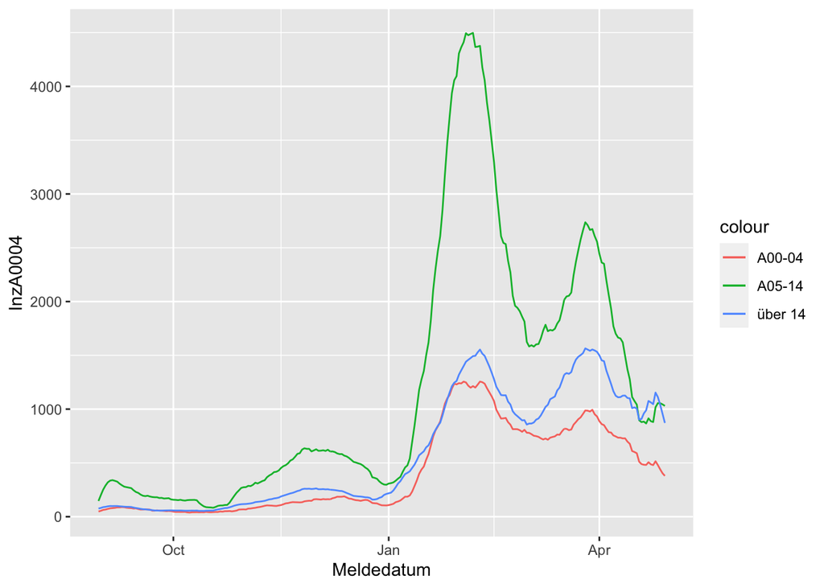

```r
# Mal nix ausfiltern, sondern im Zweifelsfall lieber ausblenden
#  select(Meldedatum,InzA0514,Inzue14,A0514)

# ggplot
library(ggplot2)
plot <- ggplot2::ggplot(data = inzidenz_alter_df %>%
                          select(Meldedatum,
                                 starts_with("Inz")),
                        aes(x=Meldedatum)) +
                          geom_line(aes(y = InzA0004, colour = "A00-04")) +
                          geom_line(aes(y = InzA0514, colour = "A05-14")) +
                          geom_line(aes(y = Inzue14, colour="über 14"))

plot
```

```r
# Richtung Datawrapper schreiben
# dw_data_to_chart(inzidenz_alter_df,id = "xiDtS")
```

# An den Schulen gefundene Inzidenz im Verhältnis

Um den Anteil der Inzidenz zu schätzen, der auf die Schultests zurückgeht, gehen wir von diesen einfachen Überlegungen aus: - Die Inzidenz 5-14 bildet ganz gut die Inzidenz an den Schulen ab (s.o.) - Alle an den Schulen gefundenen Fälle gehen in die Inzidenzberechnung 5-14 ein. - Das Verhältnis “Inzidenz nur durch Schultests” (= durch Schultests gefundene Fälle je 100.000 Schüler und Woche) zu “Inzidenz insgesamt” entspricht also dem Anteil der Schultest-Fälle an den insgesamt gefundenen Fällen unter Schülern.

[output not shown]

…ist der durchschnittliche Prozentanteil der Gesamtinzidenz, der auf die Schultests in der Altersgruppe zurückgeht.

Umgerechnet bedeutet das: Auf 100 ohne Schultests gefundene Fälle werden…

```r
zusaetzlich_gefunden <- 100 / (100-gesamt_anteil) * gesamt_anteil
print(zusaetzlich_gefunden)
```

```
## [1] 39.58166
```

…zusätzliche Fälle an den Schulen gefunden.

## Durchseuchungsquote

…wird einfach so gerechnet: Alle, die dieses Jahr - also in den letzten 4 Monaten - eine Infektion hatten, nach Altersgruppen.

```r
summe_alter_df <- rki_bl_df %>%
  # Zählung der neuen Fälle
  filter(NeuerFall %in% c(0,1)) %>%
  mutate(Meldedatum = as_date(Meldedatum)) %>%
  filter(Meldedatum >= as_date("2022-01-01")) %>%
  select(AnzahlFall,Altersgruppe) %>%
  # Nach Altersgruppe aufsummieren
  group_by(Altersgruppe) %>%
  summarize(Anzahl = sum(AnzahlFall)) %>%
  right_join(altersgruppen_df, by="Altersgruppe") %>%
  mutate(genesen = Anzahl/pop*100) %>%
  mutate(Dunkelziffer = genesen)

# an Datawrapper-Grafik übertragen

dw_data_to_chart(summe_alter_df, chart_id ="45xT7")
```

```
## Data in 45xT7 successfully updated.
```

```r
head(summe_alter_df)
```

```
## # A tibble: 6 × 5
##   Altersgruppe Anzahl     pop genesen Dunkelziffer
##   <chr>         <dbl>   <dbl>   <dbl>        <dbl>
## 1 A00-A04       40089  305325   13.1         13.1
## 2 A05-A14      209086  578413   36.1         36.1
## 3 A15-A34      390919 1472042   26.6         26.6
## 4 A35-A59      450419 2194493   20.5         20.5
## 5 A60-A79      120348 1320802    9.11         9.11
## 6 A80+          30903  422079    7.32         7.32
```